# Decomposition Techniques for Social Epidemiology: Why and How

Danish Epidemiological Society Conference

Sam Harper

2026-09-22

## Social Epidemiologic Aims

**Descriptive**  
Existence of social differences in health

**Etiologic**  
Causes of social differences in health

**Interventions**  
Policies and programs to address causes

## Enough already?

> Nevertheless, health inequalities are socially produced, and therefore, also potentially avoidable. However, effective political interventions require a scientific understanding of the causal mechanisms generating the strong and persistent correlations between social conditions and health outcomes.

[figure not shown]

### How can we find out?

Eikemo and Øversveen (2019)

## Decomposition: from description to explanation

**What changed?**  
Explaining growing or shrinking gaps

**Which ‘components’?**  
Bridge between descriptive and causal

**What if?**  
Techniques often involve ‘counterfactual’ scenarios

## Danish smoking has declined from 21% (2010) to 11% (2025)

[figure not shown]

Source: Den Nationale Sundhedsprofil 2010 (Tabel 4.1.1) and 2025 (Tabel 3.1.3), Statens Institut for Folkesundhed / Sundhedsstyrelsen.

“But obviously the next stage is to break down the twelve-monthly death rates so far examined in order to discover at what ages and from which causes inequality derives its strength”  
-Richard Titmuss (1943)

## Covered Today

**1. Kitagawa’s Decomposition**

**2. Oaxaca–Blinder Decomposition**

**3. Concentration Index Decomposition**

**4. Interventional Decomposition**

# 1. Kitagawa’s Decomposition

[figure not shown]

> If standardization alters a difference between two rates, it should be possible … to break it up into components attributable to the various factors for which the data were standardized.

### ‘Unpacking’ the difference between crude rates of two groups

Seminal paper by Kitagawa (1955)

## Consequences of ignoring composition

[figure not shown]

> may give a distorted view of the overall level of health inequality due to social class differentials as it does not take into account the changing distribution of social class within the whole population.

> changes in the distribution of social class across the population are an important contributor to recent reductions in mortality

Heller, McElduff, and Edwards (2002)

[figure not shown]

(Jiménez-Rubio and Hernández-Quevedo 2010)

## Kitagawa: Why?

Rate differences define inequalities

Rates are complex, reflect both composition and incidence

how much of it is because the groups differ in composition versus because the same factor matters differently for each group?

Group rate: $R_{i} = y_{i}/n_{i}$

Group share: $P_{i} = n_{i}/\sum_{i} n_{i}$

Crude rate: $\frac{\sum_{i=1}^{I} y_{i}}{\sum_{i=1}^{I} n_{i}} = \sum_{i=1}^{I} P_{i}R_{i}$

Standardized rate: $\frac{\sum_{i=1}^{I} y_{i}}{\sum_{i=1}^{I} s_{i}} = \sum_{i=1}^{I} S_{i}R_{i}$

where $S_{i}$ is the share of group *i* in a *standard* population ($\sum_{i} S_{i} = 1$)

| Stratum | Pop | Count | Rate |
| --- | --- | --- | --- |
| $1$ | $n_{i}$ | $y_{i}$ | $r_{i}$ |
| $\vdots$ | $\vdots$ | $\vdots$ | $\vdots$ |
| $I$ | $N$ | $Y$ | $R$ |

| Age | Group A Share | Group A Rate | Group B Share | Group B Rate |
| --- | --- | --- | --- | --- |
| Young | 30% | 10 | 50% | 20 |
| Old | 70% | 40 | 50% | 30 |
| Crude |  | 31 |  | 25 |
| Standardized to A |  | 31 |  | 27 |

### Standardization question:

What would the $A-B$ difference be *if $B$ had $A$’s age distribution*?

## Kitagawa’s key insight

[figure not shown]

> …if the difference between two standardized rates is subtracted from the corresponding difference in crude rates…the result is a weighted average of differences between the composition of the two groups.

But what are the weights?

Crude difference = $\sum P_{Ai}R_{Ai} - \sum P_{Bi}R_{Bi}$

→ Reflects differences in both rates *and* composition

Standardized difference (A as standard) = $\sum P_{Ai}R_{Ai} - \sum P_{Ai}R_{Bi}$

→ Reflects *only* differences in rates ($P_{Ai}$ is constant)

Crude - Standardized: $\sum R_{Bi}(P_{Ai}-P_{Bi})$

→ Differences in composition, *weighted* by $B$s rates!

## Need, task, and the main message

Crude difference = $\sum P_{Ai}R_{Ai} - \sum P_{Bi}R_{Bi}$  
Reflects differences in both rates *and* composition

Standardized difference (A as standard) = $\sum P_{Ai}R_{Ai} - \sum P_{Ai}R_{Bi}$  
Reflects *only* differences in rates ($P_{Ai}$ is constant)

Crude - Standardized: $\sum R_{Bi}(P_{Ai}-P_{Bi})$  
Differences in composition, *weighted* by $B$s rates!

## Applying the decomposition

$$\begin{aligned}
\underbrace{\text{Rate}_A - \text{Rate}_B}_{\text{crude difference}} &= \overbrace{\sum_i \left(\frac{R_{Ai}+R_{Bi}}{2}\right)(P_{Ai}-P_{Bi})}^{\text{composition effect}} \\
&+ \underbrace{\sum_i \left(\frac{P_{Ai}+P_{Bi}}{2}\right)(R_{Ai}-R_{Bi})}_{\text{rate effect}}
\end{aligned}$$

$R_{Ai}$ is the rate for group *A* in stratum *i*.  
$P_{Ai}$ is the *i*-stratum-specific weight in group *A*.

| Age | Group A Share | Group A Rate | Group B Share | Group B Rate |
| --- | --- | --- | --- | --- |
| Young | 30% | 10 | 50% | 20 |
| Old | 70% | 40 | 50% | 30 |

| Group | Composition effect $\frac{R_{Ai}+R_{Bi}}{2}$ | Composition effect $P_{Ai}-P_{Bi}$ | Composition effect Contribution |
| --- | --- | --- | --- |
| Young | 15 | −0.20 | −3.0 |
| Old | 35 | +0.20 | +7.0 |
| Sum |  |  | +4.0 |

| Group | Rate effect $\frac{P_{Ai}+P_{Bi}}{2}$ | Rate effect $R_{Ai}-R_{Bi}$ | Rate effect Contribution |
| --- | --- | --- | --- |
| Young | 0.40 | −10 | −4.0 |
| Old | 0.60 | +10 | +6.0 |
| Sum |  |  | +2.0 |

Total = **+6.0** = crude gap (31 − 25) →67% due to composition

Rate effect (+2) = standardized gap (28 − 26)

## Kitagawa: does the reference group matter?

| Reference | Composition | Rate | Total |
| --- | --- | --- | --- |
| A's rates | 6.0 | 0.0 | 6.0 |
| B's rates | 2.0 | 4.0 | 6.0 |
| Average (Kitagawa) | 4.0 | 2.0 | 6.0 |

Crude gap = 31 − 25 = **6** in every row; only the split changes

The one-sided rows differ by the interaction, $\sum_i (P_{Ai}-P_{Bi})(R_{Ai}-R_{Bi})$ = 4.0, which the average splits evenly

Same toy example as the previous slides. The rate difference changes sign between strata (B higher when young, lower when old), so the one-sided answers diverge sharply: A’s rates as reference attribute the whole gap to composition (rate effect 0); B’s rates give rate +4.

## Kitagawa’s three-component version

$$\underbrace{\text{Rate}_A - \text{Rate}_B}_{\text{crude difference}} = \overbrace{\sum_i R_{Bi}(P_{Ai}-P_{Bi})}^{\text{composition}} + \overbrace{\sum_i P_{Bi}(R_{Ai}-R_{Bi})}^{\text{rate}} + \overbrace{\sum_i (R_{Ai}-R_{Bi})(P_{Ai}-P_{Bi})}^{\text{interaction}}$$

| Group | Composition $R_{Bi}$ | Composition $P_{Ai}-P_{Bi}$ | Composition Contrib. |
| --- | --- | --- | --- |
| Young | 20 | −0.20 | −4.0 |
| Old | 30 | +0.20 | +6.0 |
| Sum |  |  | +2.0 |

| Group | Rate $P_{Bi}$ | Rate $R_{Ai}-R_{Bi}$ | Rate Contrib. |
| --- | --- | --- | --- |
| Young | 0.50 | −10 | −5.0 |
| Old | 0.50 | +10 | +5.0 |
| Sum |  |  | 0.0 |

| Group | Interaction $R_{Ai}-R_{Bi}$ | Interaction $P_{Ai}-P_{Bi}$ | Interaction Contrib. |
| --- | --- | --- | --- |
| Young | −10 | −0.20 | +2.0 |
| Old | +10 | +0.20 | +2.0 |
| Sum |  |  | +4.0 |

Total = +2.0 + 0.0 + 4.0 = **+6.0** = crude gap (31 − 25)

Add the interaction to composition: +6.0 and 0.0 (A’s rates). Add it to rate: +2.0 and +4.0 (B’s rates).

### What contributes to a difference?

1. Group differences in stratum-specific rates
2. Group differences in composition of strata

“Group” can be social or time

[figure not shown]

Seminal paper by Kitagawa (1955)

What accounts for differences in neonatal mortality rates across European countries?

GA-specific rates *or* distribution?

Implications for interventions?

[figure not shown]

Sartorius et al. (2024)

## Hiding in plain sight?

Both DK and AT similar and ~0.3 deaths per 1000 higher than “Top 3”

But *completely different* contributions to the difference

[figure not shown]

Sartorius et al. (2024)

### Denmark and Austria: higher NMR at lower GA, lower at higher GA

[figure not shown]

Sartorius et al. (2024)

### Distribution of GA: DK shifted left, AT shifted right

[figure not shown]

Sartorius et al. (2024)

## Covered Today

**1. Kitagawa’s Decomposition**

**2. Oaxaca–Blinder Decomposition**

**3. Concentration Index Decomposition**

**4. Interventional Decomposition**

# 2. Oaxaca–Blinder Decomposition

## Idea for Decomposition of Means

The core idea is to explain the distribution of the outcome variable in question by a set of factors that vary systematically with exposure status.

Thus, we want to know, on average, **why the mean level of health or disease differs between exposed and unexposed groups**.

Since, for most health outcomes there are multiple determinants, we may want to know which of these determinants plays more or less important roles in explaining the difference in average outcomes.

“Unpacking” or “decomposing” difference.

## Origins

[figure not shown]

Studies by Oaxaca (1973) and Blinder (1973) applied regression-based decomposition methods to analyze the wage gap between men and women and between whites and blacks in the USA.

- Focused on how much of wage gap was ‘explained’ by differences in observable characteristics

## Brief note on interpretation

Decomposition methods are based on regression analyses, and thus all of the usual caveats about good specification apply.

If regressions are purely descriptive, they reveal the associations that characterize the health inequality. Then inequality is explained in a statistical sense but implications for policies to reduce inequality are limited.

O’Donnell et al. (2008)

## Oaxaca-Blinder: Basic Idea

### What explains average differences in outcomes?

### 1. Means

#### Differences in the prevalence of determinants of outcome

### 2. Coefficients

#### Differences in the coefficient of a given determinant on the outcome (i.e., effect measure modification)

## If this sounds familiar…

O-B decomp is a generalization of Kitagawa

Equivalent for binary outcome and categorical covariates

### Why does this work?

OLS regression line always passes through $(\bar{x}, \bar{y})$ because residuals sum to zero.

[figure not shown]

### Why does this work?

The gap decomposes into **endowments** (different $\bar{x}$, same coefficients) and **coefficients** (same $\bar{x}$, different slopes/intercepts).

[figure not shown]

Equally valid to use the **exposed** group’s slope

Same total gap, but different split

[figure not shown]

See Oaxaca (1973), Blinder (1973) and Cotton (1988) for details.

## Example: Educational Differences in BMI in Italy

What is the average difference in body mass index (BMI) between those with low vs. high education?

How much of this difference is due to the fact that determinants of BMI (age, gender, smoking, drinking, income) *differ* between education groups?

Any residual difference is due to education differences in the *associations* between those risk factors and BMI — i.e., the coefficients differ.

## Example data

European Social Survey Round 11, Italy (n = 1743)

Body mass index as outcome (kg/m²): `weight / height²`

Overall difference by education: High ed (ISCED 5–7) vs Low ed (ISCED 1–4)

Potential determinants (the Xs):

- age (years)
- gender (female = 1)
- smoking (1 = current smoker)
- binge drinking (1 = monthly or more)
- married (1 = currently married)
- income decile (1–10)

## High ed BMI: 23.6, Low ed BMI: 25.2, Gap = 1.6

[figure not shown]

Source: Author’s calculations

## Differences in determinants

Differences in age, smoking, etc. could explain part of the BMI gap

[figure not shown]

Source: Author’s calculations

## Differences in coefficients

- Each covariate may have a different association with BMI by education
- Differences in *returns* form the unexplained component

[figure not shown]

## Decomposition results: variable contributions

Endowments: 38%; Coefficients: 62%

|  | Endowments Est | Endowments SE | Coefficients Est | Coefficients SE |
| --- | --- | --- | --- | --- |
| Total | 0.608 | 0.108 | 1.030 | 0.259 |
| Age (years) | 0.415 | 0.074 | 0.865 | 0.691 |
| Female | 0.080 | 0.051 | 0.466 | 0.181 |
| Current smoker | 0.004 | 0.008 | -0.145 | 0.115 |
| Binge drinking (monthly+) | 0.001 | 0.007 | 0.003 | 0.104 |
| Married | 0.012 | 0.016 | -0.037 | 0.208 |
| Income (decile) | 0.095 | 0.071 | 0.133 | 0.425 |
| Intercept | — | — | -0.256 | 0.837 |

Low ed betas used as reference; rows show each variable’s contribution to the overall gap of 1.61 kg/m²

## Summary: Endowments = 38%, Coefficients = 62%

|  | Endowments Est | Endowments SE |
| --- | --- | --- |
| Total | 0.608 | 0.108 |
| Age (years) | 0.415 | 0.074 |
| Female | 0.080 | 0.051 |
| Current smoker | 0.004 | 0.008 |
| Binge drinking (monthly+) | 0.001 | 0.007 |
| Married | 0.012 | 0.016 |
| Income (decile) | 0.095 | 0.071 |

Interpretation:

- If the low-educated had the same covariate means as the high-educated (keeping the low-educated group’s own coefficients), their BMI would be 0.608 $kg/m^2$ lower — closing 38% of the gap.
- Most of this is due to older age among the low-educated, which predicts higher BMI.

## Summary: Endowments = 38%, Coefficients = 62%

Interpretation:

- If the high-educated group’s covariates had the same relationship with BMI as they do in the low-educated group, their BMI would be 1.030 higher, accounting for 62% of the gap.
- Note smoking is negative, since smoking predicts higher BMI among the high-educated and is more common among high educated.

|  | Coefficients Est | Coefficients SE |
| --- | --- | --- |
| Total | 1.030 | 0.259 |
| Age (years) | 0.865 | 0.691 |
| Female | 0.466 | 0.181 |
| Current smoker | -0.145 | 0.115 |
| Binge drinking (monthly+) | 0.003 | 0.104 |
| Married | -0.037 | 0.208 |
| Income (decile) | 0.133 | 0.425 |
| Intercept | -0.256 | 0.837 |

## Which covariates drive the endowments?

- Variables where groups differ *and* that predict BMI contribute most
- Income and age are the biggest drivers

[figure not shown]

## Decomposition results: does the reference group matter?

[figure not shown]

Endowments account for **36–44%** of it; interaction is negligible

## **Break!** ☕

## Covered Today

**1. Kitagawa’s Decomposition**

**2. Oaxaca–Blinder Decomposition**

**3. Concentration Index Decomposition**

**4. Interventional Decomposition**

# 3. Concentration Index Decomposition

## We want to understand this:

[figure not shown]

## By evaluating something like this:

[figure not shown]

**Research Question:**

How much of inequality is due to other factors that are differential by $x$ (income) and also affect $y$ (health)?

### Relative Concentration Curve

[figure not shown]

## Relative Concentration Index

$$RCI= \frac{2}{n\mu} \sum_{i=1}^{n}y_{i}R_{i}-1$$

where

- $\mu$ is the mean of $y_{i}$ (e.g., smoking);
- $R_{i}$ is the fractional rank of the *i*th person in the socioeconomic (i.e., income) distribution.

*Decomposition*:

Develop a model for predicting $y$ using several determinants, then plug back into the $RCI$ equation

Estimates how much of the overall inequality in $y$ is due to the association between income and other factors that predict health

Kakwani, Wagstaff, and Doorslaer (1997)

### RCI Decomposition

$RCI$ is a function of health $(y_{i})$ and socioeconomic rank $(R_{i})$, i.e.
$$RCI= \frac{2}{n\mu} \sum_{i=1}^{n}{\color{red}{y_{i}}}R_{i}-1$$

Then write a regression expressing health $(y_{i})$ as a function of several $k_{i}$ determinants (e.g., age, gender, urban/rural status):
$$\color{red}{y_{i}}=\alpha + \sum{\beta_{x}x_{k_{i}}}+\epsilon_{i}$$

Wagstaff, Doorslaer, and Watanabe (2003)

### RCI Decomposition

Now re-express $RCI$ as:

$$RCI=\sum{(\beta_{k}\bar{x}_{k}/\mu)RCI_{k}}+gRCI_{e}/\mu$$

Where

- $\mu$ is the mean of $y$,
- $\bar{x}_{k}$ is the mean of determinant $x_{k}$,
- $\beta_{k}$ is the regression coefficient for $x_{k}$, and
- $RCI_{k}$ is the relative concentration index for $x_{k}$.

## Two types of ‘explained’ components

[figure not shown]

Determinant impact depends on:

1. the strength of the relationship between each factor and income $\color{blue}{RCI_{k}}$
2. the strength of the relationship between each factor and health, and its prevalence in the population (elasticity) $\color{red}{\beta_{k}\bar{x}_{k}/\mu}$

## Procedure for decomposing the Concentration Index

1. Regress $y$ (‘health’) on its determinants $(\beta_{k}x_{k})$:

$$y_{i}=\alpha + \sum{\beta_{x}x_{k_{i}}}+\epsilon_{i}$$

2. Calculate means of $y$ $(\mu)$ and all $x_{k}$ determinants
3. Calculate ($CI$) for the health variable *and* for each determinant $(CI_{k})$. This means using each determinant $x_{k}$ as the “outcome” and estimate a $CI$ for age, $CI$ for education, etc.

## Procedure for decomposing the Concentration Index

4. Absolute contribution: for each $x$ multiply ‘elasticity’ by its concentration index $(CI_{k})$:

$$(\beta_{k}\bar{x}_{k}/\mu)RCI_{k}$$

5. Calculate the % contribution of each determinant:

$$[(\beta_{k}\bar{x}_{k}/\mu)RCI_{k}]/RCI$$

## Example: Decomposing Socioeconomic Inequality in Current Smoking

## Data: European Social Survey Round 11 for Sweden

Unique

Missing Pct.

Mean

SD

Min

Median

Max

Histogram

Current smoker

2

0

0.1

0.2

0.0

0.0

1.0

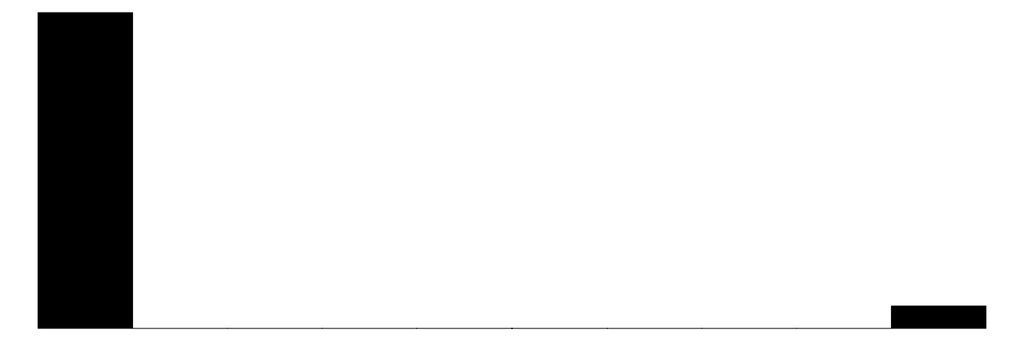

Income decile

10

0

6.6

2.6

1.0

7.0

10.0

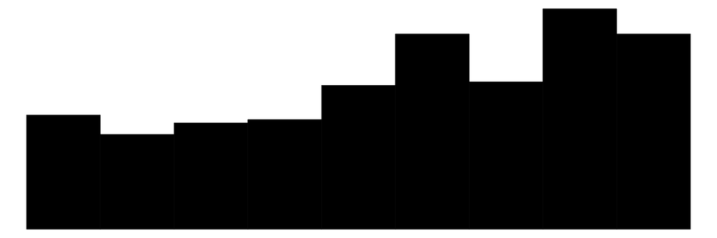

Age (years)

76

0

54.4

18.6

15.0

56.0

90.0

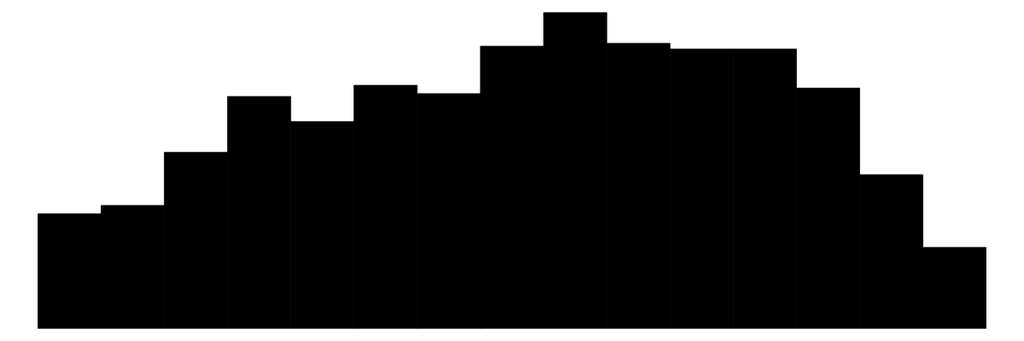

Low education (ISCED 1–4)

2

0

0.4

0.5

0.0

0.0

1.0

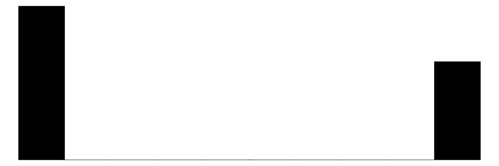

Female

2

0

0.5

0.5

0.0

0.0

1.0

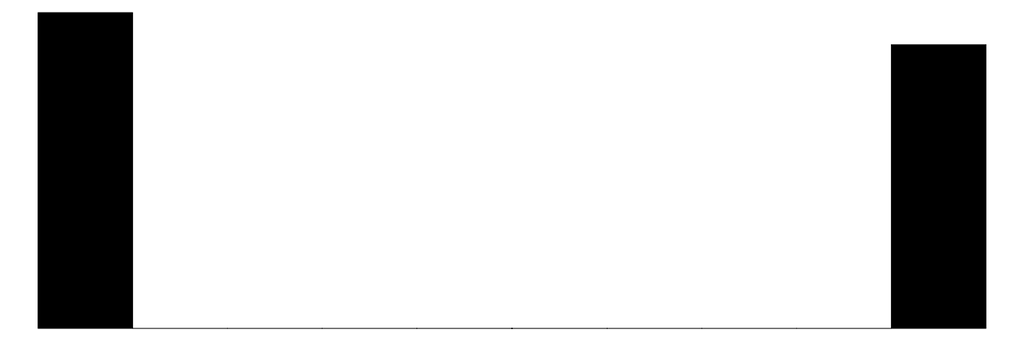

Binge drinking (monthly+)

2

0

0.5

0.5

0.0

0.0

1.0

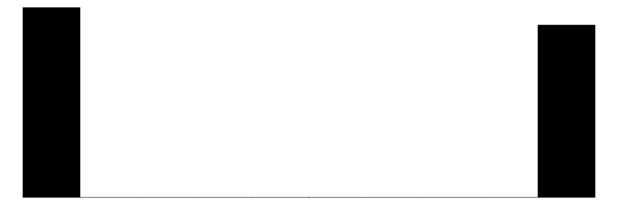

Obese (BMI ≥ 30)

2

0

0.1

0.4

0.0

0.0

1.0

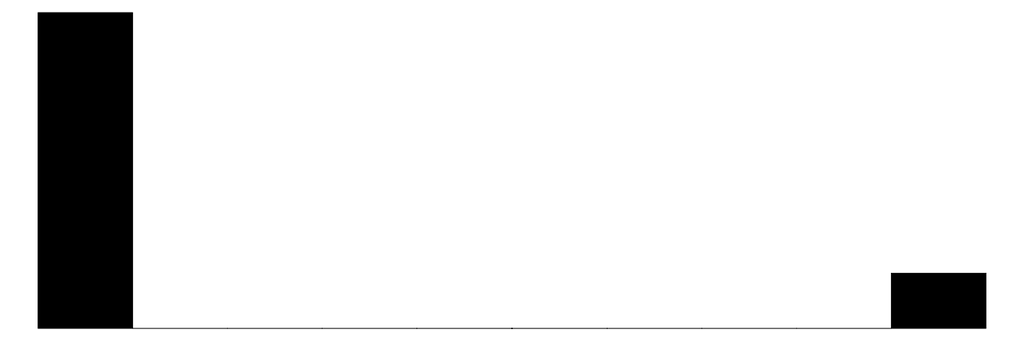

Married

2

0

0.5

0.5

0.0

0.0

1.0

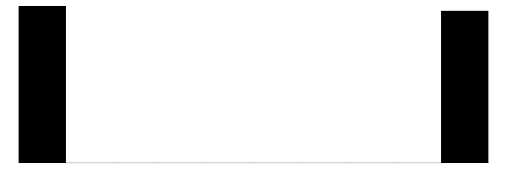

Survey weight

132

0

1.0

0.5

0.3

0.8

4.0

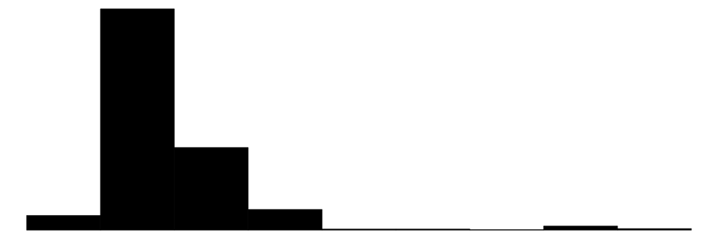

[figure not shown]

Source: Author’s calculations

### What are we explaining?

Overall CI = -0.20

Smoking *more concentrated* among the poor

[figure not shown]

## Step 1: Predictors of current smoking

| Variable | β | OR | 95% CI | p |
| --- | --- | --- | --- | --- |
| Age (years) | -0.001 | 0.999 | (0.99, 1.01) | 0.906 |
| Female | 0.141 | 1.152 | (0.73, 1.83) | 0.547 |
| Low education (ISCED 1–4) | 0.359 | 1.432 | (0.90, 2.27) | 0.130 |
| Married | -0.989 | 0.372 | (0.21, 0.65) | <0.001 |
| Binge drinking (monthly+) | 0.38 | 1.463 | (0.92, 2.32) | 0.107 |
| Obese (BMI ≥ 30) | 0.495 | 1.64 | (0.90, 2.99) | 0.106 |

## Should we include income in the regression?

Note that income decile (the *ranking variable*) is excluded from the regression.

This is deliberate, since including it can be **misleading**:

> “the residual component will be zero, or close to zero, suggesting that we have explained all or most of the variation in the Concentration Index”

Excluding it means the residual will:

- Capture unexplained income-related variation
- Allow for a direct income → smoking pathway
- Not artificially inflate the “explained” share

The appropriate interpretation is that the covariates in the model account for part of the income gradient in smoking, and the rest remains either directly attributable to income or unexplained by the observed determinants.

See Kessels and Erreygers (2013) and Erreygers and Kessels (2016)

## Step 2: Estimating elasticity for education

$$RCI=\sum{ \underbrace{(\beta_{k}\bar{x}_{k}/\mu)}_{\text{elasticity}} RCI_{k}}+gRCI_{e}/\mu$$

What about the RCI for low education?

This is Step (2): Calculate the mean of $y$ $(\mu)$ and of each of the $x_{k}$ determinants

Step 3: $RCI_{k}$

Note the y-axis is cumulative share of *low education*

The poorest 50% account for roughly 60% of the share of low educated.

[figure not shown]

This is Step (3): Calculate the $CI$ for each of the potential determinants $x_{k}$

## Step 4: Calculate contributions

Estimation for a specific factor: Low education

$$RCI=\sum{ \underbrace{(\beta_{k}\bar{x}_{k}/\mu)}_{\text{elasticity}} RCI_{k}}+gRCI_{e}/\mu$$

The elasticity of smoking (prior slide) = 0.148

Now we have $RCI_{k}$ for low education = -0.265

The contribution of low education:

$$\text{Elasticity}\times RCI_{ed} = 0.148 * -0.265 = -.039$$

**Thus low education accounts for -.039/ -0.203 = 19% of the overall** $RCI$

RCI = -0.203

(-) Binge drinking: ↑ smoking but more common at higher incomes

(+) Married: ↓ smoking but more common at higher incomes

| Variable | Elasticity | CI_k | Contribution Absolute | Contribution % |
| --- | --- | --- | --- | --- |
| Age | -0.030 | 0.001 | -0.000 | 0.0 |
| Binge drinker | 0.152 | 0.103 | 0.016 | -7.7 |
| Female | 0.060 | -0.031 | -0.002 | 0.9 |
| Obese | 0.068 | -0.013 | -0.001 | 0.4 |
| Low education | 0.144 | -0.265 | -0.038 | 18.8 |
| Married | -0.353 | 0.284 | -0.100 | 49.4 |
| Residual | — | — | -0.077 | 38.1 |

Logistic regression; marginal effects used as elasticity weights.

## Uncertainty in the RCI Decomposition

Each contribution has sampling variability:

$$\underbrace{\frac{\hat{\beta}_k \bar{x}_k}{\hat{\mu}}}_{\text{elasticity}} \times \underbrace{\widehat{RCI}_k}_{\text{inequality in }x_k}$$

Can **bootstrap** the decomp $B$ times to get empirical CIs.

[figure not shown]

See O’Donnell et al. (2008); Hosseinpoor, Doorslaer, and Speybroeck (2006)

## Caveats for decomposing the RCI

Decomposition results will be sensitive to the choice of determinants included (i.e., how well-specified the model is for predicting $y$).

The regression equations are predictive and not causal models.

Main utility is not in estimating the potential impact on $y$ of changing the distribution of socioeconomic position, but in indicating the potential role that other factors may play in generating socioeconomic inequalities in health.

## Covered Today

**1. Kitagawa’s Decomposition**

**2. Oaxaca–Blinder Decomposition**

**3. Concentration Index Decomposition**

**4. Interventional Decomposition**

# 4. Interventional Decomposition

## Why ‘interventional’?

- Kitagawa, B-0, CI decomp all ‘descriptive’
- What if we intervened?

## Many recent developments

Reconciling the descriptive framework of KBO with causal inference.

[figure not shown]

See Jackson and VanderWeele (2018); Jackson (2021); Lundberg (2024); Yu and Elwert (2025); Jackson et al. (2025); Opacic, Wei, and Zhou (2026)

## Challenges with ‘categories’

## Different from causal mediation

## Youth accident deaths: what would we intervene on?

- Danish-origin 15–24-year-olds die in accidents more often than immigrant-origin peers (IRR 0.59 first-generation, 0.93 second-generation)
- Alcohol is a plausible pathway: 16% of fatal accidents; Danish origin has 4.0 times the odds of an alcohol-related death
- Drinking itself was not measured — abstention is assumed
- Complication: immigrant-origin families are poorer, so adjusting for income *widens* the gap (0.59 → 0.39)
- **What if** Danish-origin youth drank like their immigrant-origin peers?

[figure not shown]

Udesen et al. (2023); Kruckow and Tolstrup (2024) (ethnic IRRs inverted from Kruckow supplementary table 2)

[figure not shown]

Møller et al. (2026)

## Summary

Various decomposition techniques exist that may be useful for analyzing social determinants of health:

- Regression-based decomposition of Concentration Index
- Oaxaca decomposition of mean health between groups

All of these techniques make assumptions that need to be evaluated in the course of analysis.

When used properly, decomposition techniques can help to provide key evidence on why health inequalities exist and change over time.

## References

Blinder, Alan S. 1973. “Wage Discrimination: Reduced Form and Structural Estimates.” *Journal of Human Resources* 8 (4): 436–55. https://doi.org/10.2307/144855.

Cotton, Jeremiah. 1988. “On the Decomposition of Wage Differentials.” *The Review of Economics and Statistics* 70 (2): 236. https://doi.org/10.2307/1928307.

Eikemo, Terje A., and Emil Øversveen. 2019. “Social Inequalities in Health: Challenges, Knowledge Gaps, Key Debates and the Need for New Data.” *Scandinavian Journal of Public Health* 47 (6): 593–97. https://doi.org/10.1177/1403494819866416.

Erreygers, Guido, and Roselinde Kessels. 2016. “Structural Equation Modeling for Decomposing Rank-Dependent Indicators of Socioeconomic Inequality of Health: An Empirical Study.” *Health Economics Review* 6 (1). https://doi.org/10.1186/s13561-016-0134-2.

Heller, Richard F., Patrick McElduff, and Richard Edwards. 2002. “Impact of Upward Social Mobility on Population Mortality: Analysis with Routine Data.” *BMJ* 325 (7356): 134. https://doi.org/10.1136/bmj.325.7356.134.

Hosseinpoor, Ahmad Reza, Eddy van Doorslaer, and Niko Speybroeck. 2006. “Decomposing Socioeconomic Inequality in Infant Mortality in Iran.” *International Journal of Epidemiology* 35 (5): 1211–19. https://doi.org/10.1093/ije/dyl164.

Jackson, John W. 2021. “Meaningful Causal Decompositions in Health Equity Research: Definition, Identification, and Estimation Through a Weighting Framework.” *Epidemiology* 32 (2): 282290. https://doi.org/10.1097/EDE.0000000000001319.

Jackson, John W., Yea-Jen Hsu, Raquel C. Greer, Romsai T. Boonyasai, and Chanelle J. Howe. 2025. “The Target Study: A Conceptual Model and Framework for Measuring Disparity.” *Sociological Methods & Research*, April, 00491241251314037. https://doi.org/10.1177/00491241251314037.

Jackson, John W., and Tyler J. VanderWeele. 2018. “Decomposition Analysis to Identify Intervention Targets for Reducing Disparities.” *Epidemiology* 29 (6): 825–35. https://doi.org/10.1097/EDE.0000000000000901.

Jiménez-Rubio, Dolores, and Cristina Hernández-Quevedo. 2010. “Inequalities in the Use of Health Services Between Immigrants and the Native Population in Spain: What Is Driving the Differences?” *The European Journal of Health Economics* 12 (1): 17–28. https://doi.org/10.1007/s10198-010-0220-z.

Kakwani, Nanak, Adam Wagstaff, and Eddy van Doorslaer. 1997. “Socioeconomic Inequalities in Health: Measurement, Computation, and Statistical Inference.” *Journal of Econometrics* 77 (1): 87–103. https://doi.org/10.1016/S0304-4076(96)01807-6.

Kessels, Roselinde, and Guido Erreygers. 2013. “Regression-Based Decompositions of Rank-Dependent Indicators of Socioeconomic Inequality of Health.” In *Health and Inequality*, 227–59. Emerald Group Publishing Limited. https://doi.org/10.1108/s1049-2585(2013)0000021010.

Kitagawa, Evelyn M. 1955. “Components of a Difference Between Two Rates.” *Journal of the American Statistical Association* 50 (272): 1168–94. https://doi.org/10.2307/2281213.

Kruckow, Sofie, and Janne S. Tolstrup. 2024. “All Cause and Cause Specific Mortality in 15-24-Year-Olds in Denmark 2010 to 2022: Nationwide Study of Socioeconomic Predictors.” *BMJ Medicine* 3 (1): e000685. https://doi.org/10.1136/bmjmed-2023-000685.

Lundberg, Ian. 2024. “The Gap-Closing Estimand: A Causal Approach to Study Interventions That Close Disparities Across Social Categories.” *Sociological Methods & Research* 53 (2): 507–70. https://doi.org/10.1177/00491241211055769.

Møller, Amalie Lykkemark, Kathrine Kold Sørensen, Nerissa Nance, Julie Thietje Mortensen, Thomas Alexander Gerds, Christian Torp-Pedersen, and Helene Charlotte Wiese Rytgaard. 2026. “Estimating Effects of Targeted Public Health Interventions Using the Interventional Disparity Indirect Effect Among the Exposed.” *Journal of Epidemiology and Community Health* 80 (5): 309–15. https://doi.org/10.1136/jech-2025-224627.

O’Donnell, Owen, Eddy van Doorslaer, Adam Wagstaff, and Magnus Lindelow. 2008. *Analyzing Health Equity Using Household Survey Data*. Washington, DC: World Bank.

Oaxaca, Ronald. 1973. “Male-Female Wage Differentials in Urban Labor Markets.” *International Economic Review* 14 (3): 693–709. https://doi.org/10.2307/2525981.

Opacic, Aleksei, Lai Wei, and Xiang Zhou. 2026. “Disparity Analysis: A Tale of Two Approaches.” *Journal of the Royal Statistical Society Series A: Statistics in Society* 189 (2): 805–33. https://doi.org/10.1093/jrsssa/qnaf008.

Sartorius, Victor, Marianne Philibert, Kari Klungsoyr, Jeannette Klimont, Katarzyna Szamotulska, Zeljka Drausnik, Petr Velebil, et al. 2024. “Neonatal Mortality Disparities by Gestational Age in European Countries.” *JAMA Network Open* 7 (8): e2424226. https://doi.org/10.1001/jamanetworkopen.2024.24226.

Udesen, Caroline Holt, Signe Skovgaard Hviid, Ulrik Becker, and Janne S. Tolstrup. 2023. “Alcohol-Related Mortality in 15-24-Year-Olds in Denmark (2010-2019): A Nationwide Exploratory Study of Circumstances and Socioeconomic Predictors.” *The Lancet Regional Health - Europe* 29 (June): 100620. https://doi.org/10.1016/j.lanepe.2023.100620.

Wagstaff, Adam, Eddy van Doorslaer, and Naoko Watanabe. 2003. “On Decomposing the Causes of Health Sector Inequalities with an Application to Malnutrition Inequalities in Vietnam.” *Journal of Econometrics* 112 (1): 207–23. https://doi.org/10.1016/S0304-4076(02)00161-6.

Yu, Ang, and Felix Elwert. 2025. “Nonparametric Causal Decomposition of Group Disparities.” *The Annals of Applied Statistics* 19 (1). https://doi.org/10.1214/24-AOAS1990.